# Accessing a Web Feature Service with Python

This notebook demonstrates how to programmatically access an OGC Web Feature Service from the National Environmental Information Infrastructure using Python. In this example the service endpoint is known but if it wasn't it could be found from the catalogue (see Accessing the Catalogue example).

To access the WFS service we can use the OWSLib Python library.

First we need to import the WebFeatureService class

```python
from owslib.wfs import WebFeatureService
```

Now we can instantiate an OWSLib object that connects to the Web Feature Service, and check the title and abstract of the service.

```python
wfs=WebFeatureService('http://www.environment.gov.au/mapping/services/ogc_services/World_Heritage_Areas_label/MapServer/WFSServer')
```

The 'dir' python command is useful for interrogating objects. Here we can see that the WebFeatureService object we have just created has various properties such as 'identification' and 'provider':

```python
dir(wfs)
```

```
['__class__',
 '__delattr__',
 '__dict__',
 '__dir__',
 '__doc__',
 '__eq__',
 '__format__',
 '__ge__',
 '__getattribute__',
 '__getitem__',
 '__gt__',
 '__hash__',
 '__init__',
 '__init_subclass__',
 '__le__',
 '__lt__',
 '__module__',
 '__ne__',
 '__new__',
 '__reduce__',
 '__reduce_ex__',
 '__repr__',
 '__setattr__',
 '__sizeof__',
 '__str__',
 '__subclasshook__',
 '__weakref__',
 '_buildMetadata',
 '_capabilities',
 '_makeStringIO',
 'contents',
 'exceptions',
 'getOperationByName',
 'get_schema',
 'getcapabilities',
 'getfeature',
 'identification',
 'items',
 'operations',
 'password',
 'provider',
 'timeout',
 'updateSequence',
 'url',
 'username',
 'version']
```

You could use dir() further to interrogate these objects e.g. dir(wfs.identification).

Now let's look at some of the properties of the WFS:

```python
wfs.identification.title
```

```
'World Heritage Areas label'
```

```python
wfs.identification.abstract
```

```
'Service for Australian properties on the World Heritage List including labels'
```

```python
wfs.identification.keywords
```

```
['MNES; EPBC; OSS, UNESCO; Heritage; WorldHeritage']
```

```python
wfs.provider.name
```

```
'World_Heritage_Areas_label'
```

wfs.contents is a dictionary of available feature types. Here there is only one feature type.

```python
sorted(wfs.contents.keys())
```

```
['ogc_services_World_Heritage_Areas_label:World_Heritage_Areas_Australia_label']
```

As before dir() can be used to see what properties are available for the chosen feature type. These properties (e.g. boundingBox, timepositions could be used to inform a filter query.

```python
dir(wfs.contents['ogc_services_World_Heritage_Areas_label:World_Heritage_Areas_Australia_label'])
```

```
['__class__',
 '__delattr__',
 '__dict__',
 '__dir__',
 '__doc__',
 '__eq__',
 '__format__',
 '__ge__',
 '__getattribute__',
 '__gt__',
 '__hash__',
 '__init__',
 '__init_subclass__',
 '__le__',
 '__lt__',
 '__module__',
 '__ne__',
 '__new__',
 '__reduce__',
 '__reduce_ex__',
 '__repr__',
 '__setattr__',
 '__sizeof__',
 '__str__',
 '__subclasshook__',
 '__weakref__',
 'abstract',
 'boundingBox',
 'boundingBoxWGS84',
 'crsOptions',
 'defaulttimeposition',
 'id',
 'keywords',
 'metadataUrls',
 'styles',
 'timepositions',
 'title',
 'verbOptions']
```

Here is a simple request to get some of the features. To minimise the size of the request a maximum of 10 is requested.

```python
features = wfs.getfeature(typename=['ogc_services_World_Heritage_Areas_label:World_Heritage_Areas_Australia_label'], maxfeatures=10, propertyname=None)
```

```python
wfs_response=features.read()
```

```python
By examining the first few characters of the response it can be seen that the data has come back as a WFS FeatureCollection in XML format.
```

```python
wfs_response[:200]
```

```
b"<wfs:FeatureCollection xsi:schemaLocation='http://www.environment.gov.au/mapping/services/ogc_services//World_Heritage_Areas_label/MapServer/WFSServer http://www.environment.gov.au/mapping/services/og"
```

To decipher the response the ElementTree library can be used to parse the XML. The ElementTree library is wrapped in OWSLib as etree. This part of the code example is specific to this WFS response from this service. Different WFS services will return different data. In order to examine the data the output structure must be understood. The only way to do this is to examine the returned data. Once the returned data structure is understood code can be written to perform automated queries.

```python
from owslib.etree import etree
```

The WFS response (XML) can be parsed into an ElementTree object.

```python
xmltree=etree.fromstring(wfs_response)
```

```python
xmltree
```

```
<Element {http://www.opengis.net/wfs}FeatureCollection at 0x18c88defb88>
```

Now we can interrogate the XML using XPath or by navigating the tree hierarchy. First, we will find the features using an XPath expression.

```python
features=xmltree.findall('.//{http://www.opengis.net/gml}featureMember')
```

```python
for feature in features:
    print (feature[0][3].text)  #[0][3] is the NAME property - found by examining the XML
```

```
Australian Convict Sites (Hyde Park Barracks Buffer Zone)
Australian Convict Sites (Hyde Park Barracks)
Australian Convict Sites (Kingston and Arthurs Vale Historic Area)
Shark Bay, Western Australia
Uluru - Kata Tjuta National Park
Kakadu National Park
Great Barrier Reef
Wet Tropics of Queensland
Lord Howe Island Group
Lord Howe Island Group
```

Let's select a particular feature:

```python
for feature in features:
    if feature[0][3].text =='Great Barrier Reef':
        gbreef=feature
```

```python
gbreef.findall('.//{http://www.opengis.net/gml}Polygon')
```

```
[<Element {http://www.opengis.net/gml}Polygon at 0x18c88df1988>]
```

```python
for polygon in gbreef.findall('{http://www.opengis.net/gml}Polygon'):
...     for coord in polygon.findall(
...             "{http://www.opengis.net/gml}outerBoundaryIs/"
...             "{http://www.opengis.net/gml}LinearRing/"
...             "{http://www.opengis.net/gml}coordinates"):
...         print(
...             coord.findtext("{http://www.opengis.net/gml}X"),
...             coord.findtext("{http://www.opengis.net/gml}Y"))
```

```python
coords=gbreef.findall('.//{http://www.opengis.net/gml}Polygon')[0][0][0][0].text  #need to refine this code...
```

```python
coordslist=[]
```

```python
for pair in coords.split(' '):
    if len(pair)>1:
        splitpair=pair.split(',')
        coordslist.append((float(splitpair[0]),float(splitpair[1])))
```

Check the first few coordinates:

```python
coordslist[:10]
```

```
[(145.00105291299997, -10.681888948999983),
 (145.00099999999998, -10.681889098999989),
 (144.999469042, -10.681893446000004),
 (144.95375270199997, -10.68217242899999),
 (144.90805435899995, -10.682446901999981),
 (144.86234701399997, -10.682721381000022),
 (144.81664416700005, -10.682982360999972),
 (144.770950321, -10.683234340000013),
 (144.72525197699997, -10.683486318999996),
 (144.67955363399994, -10.683729303000007)]
```

```python
%matplotlib inline
```

```python
from matplotlib import pyplot as plt
```

```python
import numpy as np
```

```python
from shapely.geometry.polygon import LinearRing, Polygon
```

```python
poly=Polygon(coordslist)
```

```python
x,y=poly.exterior.xy
```

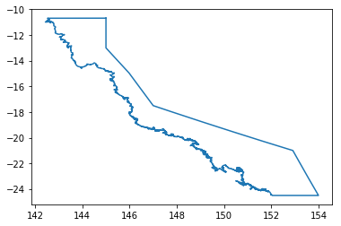

```python
plt.plot(x,y)
```

To make this plot more interesting we can view it on top of a basemap. This can be done using the matplotlib basemap module as shown below.

```python
from mpl_toolkits.basemap import Basemap
```

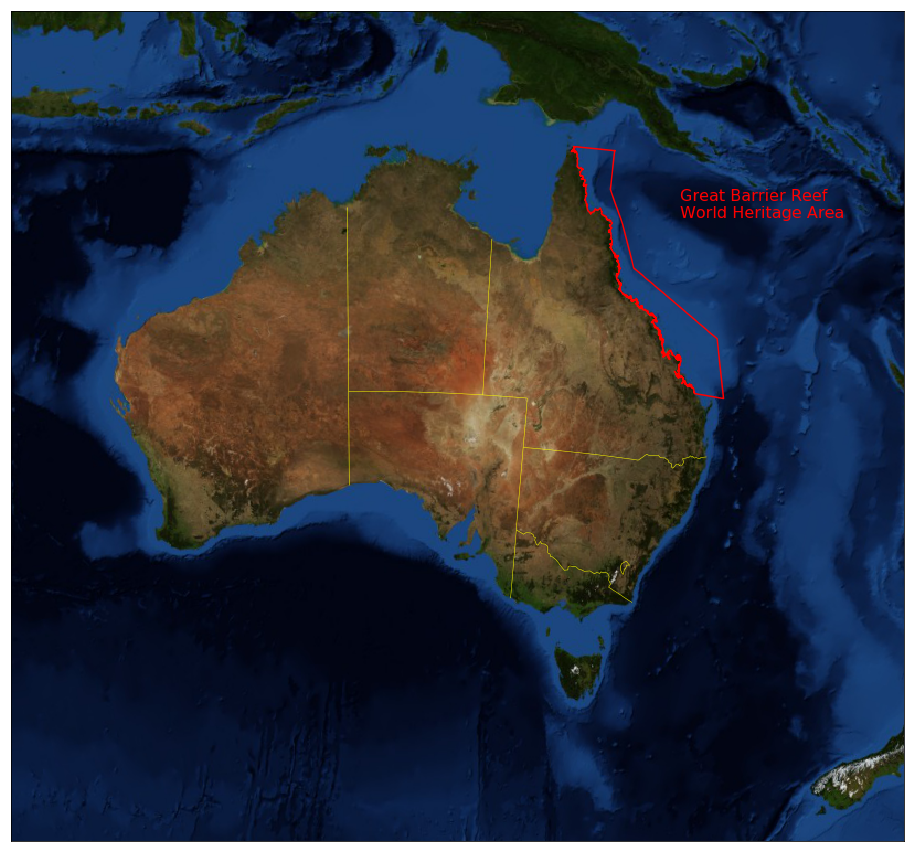

```python
plt.figure(figsize=(16,16))
map = Basemap(llcrnrlon=100, llcrnrlat=-50,
    urcrnrlon=160, urcrnrlat=-0,
            rsphere=(6378137.00,6356752.3142),\
            resolution='l',area_thresh=1000.,projection='lcc',\
            lat_0=-25,lon_0=130)

map.bluemarble()
map.drawstates(color='Yellow')
x1,y1=map(x,y)
plt.plot(x1,y1,color='Red')
plt.annotate('Great Barrier Reef \nWorld Heritage Area', xy=(0.75, 0.75),color='Red', size=16, xycoords='axes fraction')
plt.show()
```

This example has shown how to query data from a WFS and interrogate the response to extract useful information. The query to the service was straightforward but the more complex part was intepreting the data that was returned.

Go back to index.